# ESDSWRF Oat-Pea Polyculture Manuscript Analysis

### Plot

Merge emmeans

```r
keep = c('PLANTING', 'CROP', '.group')

has_flax = grepl('flax', emeans$CROP)
emeans[has_flax, '.group'] = ''

emeans %<>%
  .[, keep] %>%
  merge(emeans1)

emeans[, '.group'] = with(emeans,
                          paste0(trimws(.GROUP),
                                 trimws(.group)))
```

construct plotting and labelling dataframes

```r
prettyplanting = c(early = 'Planting A',
                   late = 'Planting B')
grp = 'CROP+PLANTING'



annotate_df = c('CROP', 'PLANTING') %>%
  df[, .] %>%
  unique %>%
  merge(emeans, all.y=TRUE)
annotate_df$.group %<>% trimws()

grpY = group_Y(resp, grp, data=df)
annotate_df %<>% merge(grpY, all.x=TRUE)

pltdf = c('CROP', 'PLANTING', resp) %>%
  df[, .] %>%
  rbind(
    data.frame(CROP='oat-pea-flax' %>%
                 factor(levels=levels(df$CROP)),
               PLANTING='late' %>%
                 factor(levels=levels(df$PLANTING)),
               X=0
               )
    %>% set_names(c('CROP', 'PLANTING', resp))
  )
pltdf$prettyplanting = pltdf$PLANTING %>%
  as.character %>%
  prettyplanting[.]
annotate_df$prettyplanting = annotate_df$PLANTING %>%
  as.character %>%
  prettyplanting[.]
```

Plot

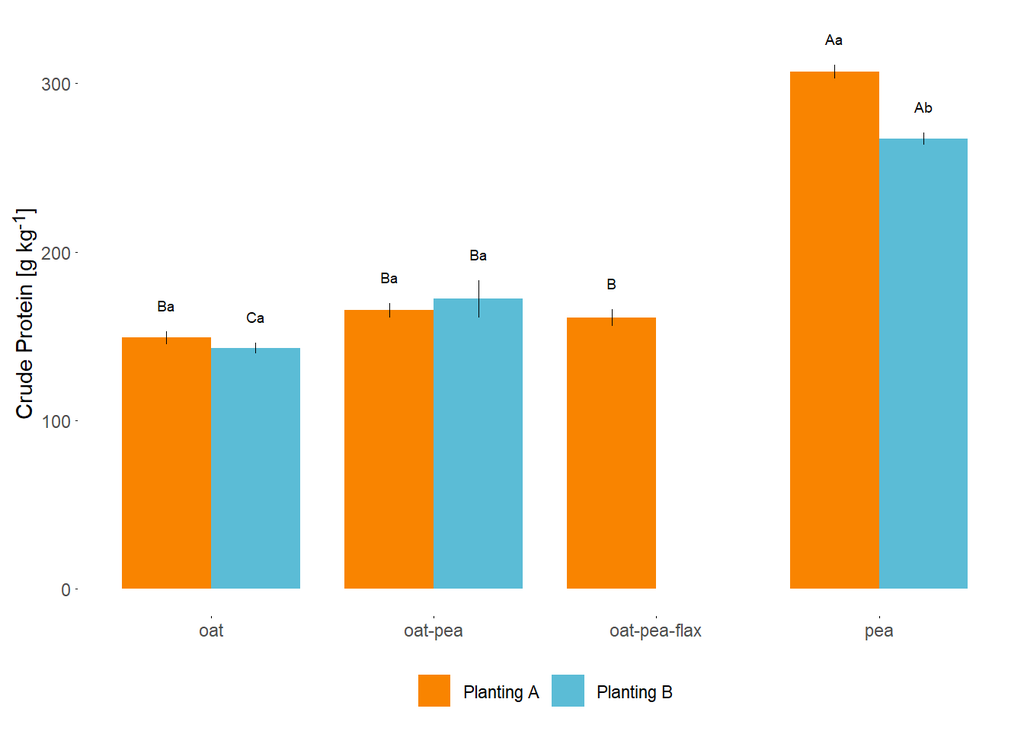

```r
dodger = position_dodge(width=0.8)

plt = ggplot(pltdf,
             aes(x=CROP,
                 y=.data[[resp]],
                 fill=prettyplanting)) +
  scale_fill_manual(values=colors[3:4]) +
  stat_summary(fun=mean,
               geom='bar',
               position=dodger,
               width=0.8) +
  stat_summary(fun.data=mean_se,
               geom='errorbar',
               width=0,
               position=dodger,
               linewidth=0.1) +
  geom_text(data=annotate_df,
            aes(x=CROP,
                y=Y,
                label=.group),
            size=2.5,
            position=dodger) +
  labs(x=NULL,
       y='Crude Protein [g kg<sup>-1</sup>]',
       fill=NULL)
plt %<>% gg_formatter

plt
```

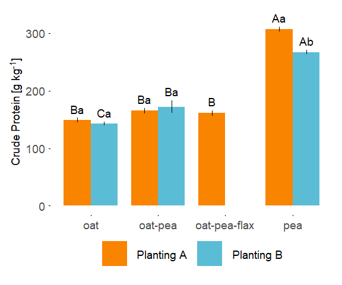

```r
plt_protein = text_sizer(plt)
plt_protein
```

Exact means and standard errors are:

```r
get_mean_se(paste(resp, pred, sep='~') %>% formula,
            data=df)
```

| CROP | PLANTING | COMBO_CP.MEAN | COMBO_CP.SE |
| --- | --- | --- | --- |
| oat | early | 149.1571 | 3.789917 |
| oat-pea | early | 165.3018 | 4.385175 |
| oat-pea-flax | early | 161.0344 | 4.944556 |
| pea | early | 307.1029 | 4.091837 |
| oat | late | 143.0106 | 3.254695 |
| oat-pea | late | 172.1903 | 11.048116 |
| pea | late | 267.2133 | 3.740838 |

## TDN

```r
resp = 'COMBO_TDN'
pred = 'CROP*PLANTING'
err = '(1|REP/PLANTING)'
dd = subset(df, CROP != 'oat-pea-flax')

# df[, resp] = df$COMBO_CP * df$COMBO_YIELD_HAND
ff = paste(resp, '~', pred, '+', err) %>%
  formula

mod = lmer(ff, data=df)
av = Anova(mod, test.statistic='F')
av
```

|  | F | Df | Df.res | Pr(>F) |
| --- | --- | --- | --- | --- |
| CROP | 23.3642566 | 3 | 15.120000 | 6.282215e-06 |
| PLANTING | 0.1432001 | 1 | 4.053619 | 7.241056e-01 |
| CROP:PLANTING | 1.3905671 | 2 | 15.120000 | 2.790195e-01 |

```r
anova_table = make_anova_table(av, append_to=anova_table)
```

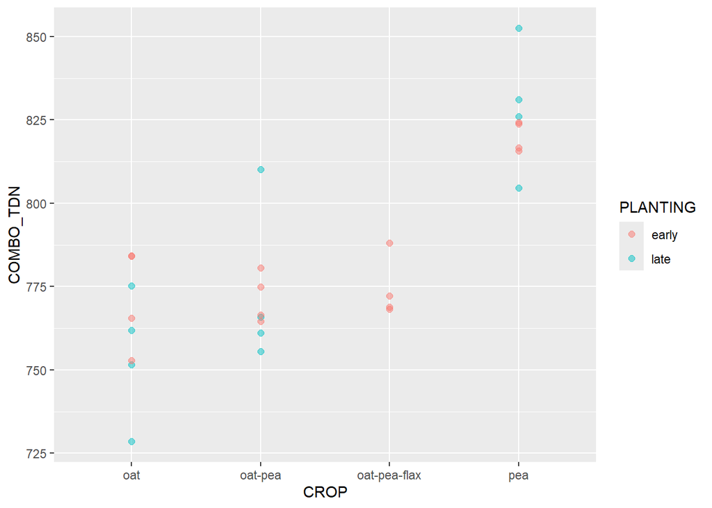

```r
ggplot(df,
       aes(x=CROP,
           y=.data[[resp]],
           color=PLANTING)) +
  geom_point(alpha=0.5,
             size=2)
```

All crops produced similar amounts of protein across planting dates, despite the very different grain ratios of the oat-pea mix.

### Comparisions

*Planting date within crop*

```r
emeans = emmeans(mod, ~PLANTING | CROP) %>%
  cld(Letters=letters,
      reverse=TRUE,
      adjust=p_adjust)
emeans
```

|  | PLANTING | CROP | emmean | SE | df | lower.CL | upper.CL | .group |
| --- | --- | --- | --- | --- | --- | --- | --- | --- |
| 2 | early | oat | 771.6750 | 8.013035 | 21 | 752.3328 | 791.0172 | a |
| 1 | late | oat | 754.3000 | 8.013035 | 21 | 734.9578 | 773.6422 | a |
| 3 | late | oat-pea | 773.1570 | 8.013035 | 21 | 753.8148 | 792.4992 | a |
| 4 | early | oat-pea | 771.6595 | 8.013035 | 21 | 752.3173 | 791.0017 | a |
| 5 | late | oat-pea-flax | NA | NA | NA | NA | NA |  |
| 6 | early | oat-pea-flax | 774.3302 | 8.013035 | 21 | 757.6662 | 790.9942 | a |
| 7 | late | pea | 828.5500 | 8.013035 | 21 | 809.2078 | 847.8922 | a |
| 8 | early | pea | 820.1000 | 8.013035 | 21 | 800.7578 | 839.4422 | a |

*Crop within planting date*

```r
emeans1 = emmeans(mod, ~CROP | PLANTING) %>%
  cld(Letters=LETTERS,
      reverse=TRUE,
      adjust=p_adjust)
emeans1
```

|  | CROP | PLANTING | emmean | SE | df | lower.CL | upper.CL | .group |
| --- | --- | --- | --- | --- | --- | --- | --- | --- |
| 2 | pea | early | 820.1000 | 8.013035 | 21 | 798.2113 | 841.9887 | A |
| 1 | oat-pea-flax | early | 774.3302 | 8.013035 | 21 | 752.4416 | 796.2189 | B |
| 3 | oat | early | 771.6750 | 8.013035 | 21 | 749.7863 | 793.5637 | B |
| 4 | oat-pea | early | 771.6595 | 8.013035 | 21 | 749.7709 | 793.5482 | B |
| 5 | oat-pea-flax | late | NA | NA | NA | NA | NA |  |
| 6 | pea | late | 828.5500 | 8.013035 | 21 | 807.7053 | 849.3947 | A |
| 8 | oat-pea | late | 773.1570 | 8.013035 | 21 | 752.3123 | 794.0017 | B |
| 7 | oat | late | 754.3000 | 8.013035 | 21 | 733.4553 | 775.1447 | B |

```r
colnames(emeans1) %<>% gsub('.group', '.GROUP', .)
```

*Main effects*

```r
emmeans(mod, ~CROP) %>%
  cld(Letters=letters,
      reverse=TRUE,
      adjust=p_adjust)
```

```
## NOTE: Results may be misleading due to involvement in interactions
```

|  | CROP | emmean | SE | df | lower.CL | upper.CL | .group |
| --- | --- | --- | --- | --- | --- | --- | --- |
| 1 | oat-pea-flax | NA | NA | NA | NA | NA |  |
| 2 | pea | 824.3250 | 5.666071 | 16.25806 | 809.2071 | 839.4429 | a |
| 4 | oat-pea | 772.4083 | 5.666071 | 16.25806 | 757.2904 | 787.5261 | b |
| 3 | oat | 762.9875 | 5.666071 | 16.25806 | 747.8696 | 778.1054 | b |

### Plot

Merge emmeans

```r
keep = c('PLANTING', 'CROP', '.group')

has_flax = grepl('flax', emeans$CROP)
emeans[has_flax, '.group'] = ''

emeans %<>%
  .[, keep] %>%
  merge(emeans1)

emeans[, '.group'] = with(emeans,
                          paste0(trimws(.GROUP),
                                 trimws(.group)))
```

construct plotting and labelling dataframes

```r
prettyplanting = c(early = 'Planting A',
                   late = 'Planting B')
grp = 'CROP+PLANTING'



annotate_df = c('CROP', 'PLANTING') %>%
  df[, .] %>%
  unique %>%
  merge(emeans, all.y=TRUE)
annotate_df$.group %<>% trimws()

grpY = group_Y(resp, grp, data=df)
annotate_df %<>% merge(grpY, all.x=TRUE)

pltdf = c('CROP', 'PLANTING', resp) %>%
  df[, .] %>%
  rbind(
    data.frame(CROP='oat-pea-flax' %>%
                 factor(levels=levels(df$CROP)),
               PLANTING='late' %>%
                 factor(levels=levels(df$PLANTING)),
               X=0
               )
    %>% set_names(c('CROP', 'PLANTING', resp))
  )
pltdf$prettyplanting = pltdf$PLANTING %>%
  as.character %>%
  prettyplanting[.]
annotate_df$prettyplanting = annotate_df$PLANTING %>%
  as.character %>%
  prettyplanting[.]
```

Plot

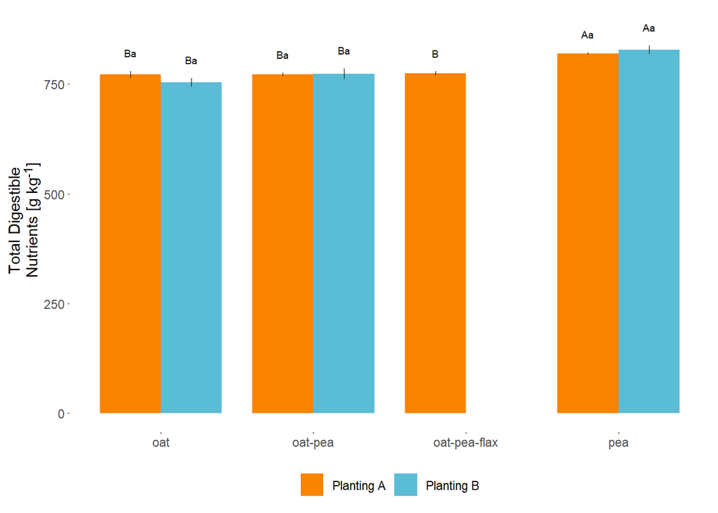

```r
dodger = position_dodge(width=0.8)

plt = ggplot(pltdf,
             aes(x=CROP,
                 y=.data[[resp]],
                 fill=prettyplanting)) +
  scale_fill_manual(values=colors[3:4]) +
  stat_summary(fun=mean,
               geom='bar',
               position=dodger,
               width=0.8) +
  stat_summary(fun.data=mean_se,
               geom='errorbar',
               width=0,
               position=dodger,
               linewidth=0.1) +
  geom_text(data=annotate_df,
            aes(x=CROP,
                y=Y,
                label=.group),
            size=2.5,
            position=dodger) +
  labs(x=NULL,
       y='Total Digestible<br>Nutrients [g kg<sup>-1</sup>]',
       fill=NULL)
plt %<>% gg_formatter

plt
```

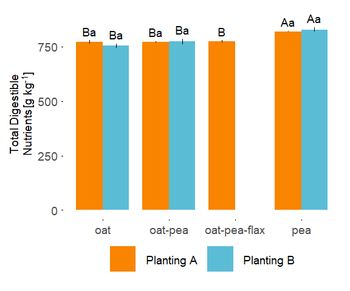

```r
plt_TDN = text_sizer(plt)
plt_TDN
```

Exact means and standard errors are:

```r
get_mean_se(paste(resp, pred, sep='~') %>% formula,
            data=df)
```

| CROP | PLANTING | COMBO_TDN.MEAN | COMBO_TDN.SE |
| --- | --- | --- | --- |
| oat | early | 771.6750 | 7.661742 |
| oat-pea | early | 771.6595 | 3.730729 |
| oat-pea-flax | early | 774.3302 | 4.675748 |
| pea | early | 820.1000 | 2.290196 |
| oat | late | 754.3000 | 9.863654 |
| oat-pea | late | 773.1570 | 12.480264 |
| pea | late | 828.5500 | 9.832811 |

## ADF

```r
resp = 'COMBO_ADF'
pred = 'CROP*PLANTING'
err = '(1|REP/PLANTING)'
dd = subset(df, CROP != 'oat-pea-flax')

# df[, resp] = df$COMBO_CP * df$COMBO_YIELD_HAND
ff = paste(resp, '~', pred, '+', err) %>%
  formula

mod = lmer(ff, data=df)
av = Anova(mod, test.statistic='F')
av
```

|  | F | Df | Df.res | Pr(>F) |
| --- | --- | --- | --- | --- |
| CROP | 39.7761227 | 3 | 15.120000 | 2.066146e-07 |
| PLANTING | 0.1858791 | 1 | 4.053619 | 6.883081e-01 |
| CROP:PLANTING | 1.5892732 | 2 | 15.120000 | 2.363427e-01 |

```r
anova_table = make_anova_table(av, append_to=anova_table)
```

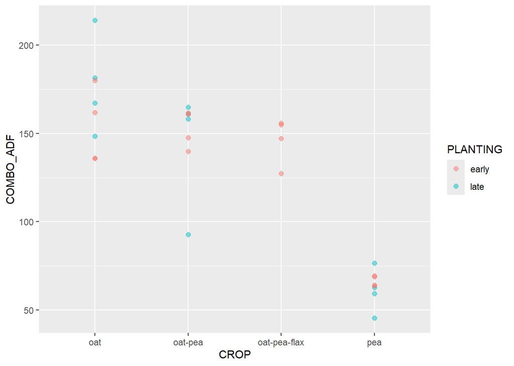

```r
ggplot(df,
       aes(x=CROP,
           y=.data[[resp]],
           color=PLANTING)) +
  geom_point(alpha=0.5,
             size=2)
```

```r
emeans = emmeans(mod, ~PLANTING | CROP) %>%
  cld(Letters=letters,
      reverse=TRUE,
      adjust=p_adjust)
emeans
```

|  | PLANTING | CROP | emmean | SE | df | lower.CL | upper.CL | .group |
| --- | --- | --- | --- | --- | --- | --- | --- | --- |
| 1 | late | oat | 177.83696 | 10.13772 | 21 | 153.36607 | 202.30786 | a |
| 2 | early | oat | 153.45528 | 10.13772 | 21 | 128.98439 | 177.92617 | a |
| 4 | early | oat-pea | 152.45142 | 10.13772 | 21 | 127.98053 | 176.92231 | a |
| 3 | late | oat-pea | 144.27763 | 10.13772 | 21 | 119.80674 | 168.74853 | a |
| 5 | late | oat-pea-flax | NA | NA | NA | NA | NA |  |
| 6 | early | oat-pea-flax | 146.36491 | 10.13772 | 21 | 125.28236 | 167.44746 | a |
| 8 | early | pea | 66.50427 | 10.13772 | 21 | 42.03338 | 90.97516 | a |
| 7 | late | pea | 61.00247 | 10.13772 | 21 | 36.53158 | 85.47336 | a |

*Crop within planting date*

```r
emeans1 = emmeans(mod, ~CROP | PLANTING) %>%
  cld(Letters=LETTERS,
      reverse=TRUE,
      adjust=p_adjust)
emeans1
```

|  | CROP | PLANTING | emmean | SE | df | lower.CL | upper.CL | .group |
| --- | --- | --- | --- | --- | --- | --- | --- | --- |
| 4 | oat | early | 153.45528 | 10.13772 | 21 | 125.76275 | 181.14781 | A |
| 3 | oat-pea | early | 152.45142 | 10.13772 | 21 | 124.75889 | 180.14395 | A |
| 2 | oat-pea-flax | early | 146.36491 | 10.13772 | 21 | 118.67238 | 174.05744 | A |
| 1 | pea | early | 66.50427 | 10.13772 | 21 | 38.81174 | 94.19680 | B |
| 8 | oat-pea-flax | late | NA | NA | NA | NA | NA |  |
| 6 | oat | late | 177.83696 | 10.13772 | 21 | 151.46520 | 204.20873 | A |
| 5 | oat-pea | late | 144.27763 | 10.13772 | 21 | 117.90587 | 170.64940 | B |
| 7 | pea | late | 61.00247 | 10.13772 | 21 | 34.63070 | 87.37423 | C |

```r
colnames(emeans1) %<>% gsub('.group', '.GROUP', .)
```

*Main effects*

```r
emeans2 = emmeans(mod, ~CROP) %>%
  cld(Letters=LETTERS,
      reverse=TRUE,
      adjust=p_adjust)
```

```
## NOTE: Results may be misleading due to involvement in interactions
```

```r
emeans2
```

|  | CROP | emmean | SE | df | lower.CL | upper.CL | .group |
| --- | --- | --- | --- | --- | --- | --- | --- |
| 4 | oat-pea-flax | NA | NA | NA | NA | NA |  |
| 2 | oat | 165.64612 | 7.168452 | 16.25806 | 146.51966 | 184.77258 | A |
| 1 | oat-pea | 148.36453 | 7.168452 | 16.25806 | 129.23807 | 167.49099 | A |
| 3 | pea | 63.75337 | 7.168452 | 16.25806 | 44.62691 | 82.87983 | B |

### Plot

Merge emmeans

```r
keep = c('PLANTING', 'CROP', '.group')

has_flax = grepl('flax', emeans$CROP)
emeans[has_flax, '.group'] = ''

emeans %<>%
  .[, keep] %>%
  merge(emeans1)

emeans[, '.group'] = with(emeans,
                          paste0(trimws(.GROUP),
                                 trimws(.group)))
```

construct plotting and labelling dataframes

```r
prettyplanting = c(early = 'Planting A',
                   late = 'Planting B')
grp = 'CROP+PLANTING'



annotate_df = c('CROP', 'PLANTING') %>%
  df[, .] %>%
  unique %>%
  merge(emeans, all.y=TRUE)
annotate_df$.group %<>% trimws()

grpY = group_Y(resp, grp, data=df)
annotate_df %<>% merge(grpY, all.x=TRUE)

pltdf = c('CROP', 'PLANTING', resp) %>%
  df[, .] %>%
  rbind(
    data.frame(CROP='oat-pea-flax' %>%
                 factor(levels=levels(df$CROP)),
               PLANTING='late' %>%
                 factor(levels=levels(df$PLANTING)),
               X=0
               )
    %>% set_names(c('CROP', 'PLANTING', resp))
  )
pltdf$prettyplanting = pltdf$PLANTING %>%
  as.character %>%
  prettyplanting[.]
annotate_df$prettyplanting = annotate_df$PLANTING %>%
  as.character %>%
  prettyplanting[.]
```

Plot

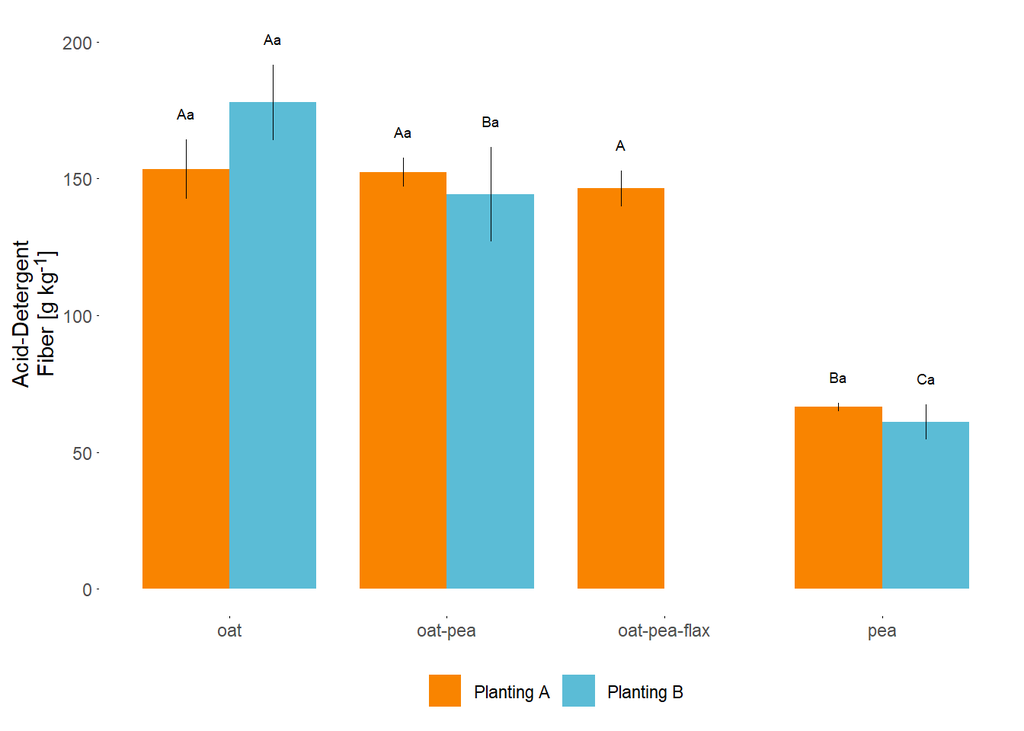

```r
dodger = position_dodge(width=0.8)

plt = ggplot(pltdf,
             aes(x=CROP,
                 y=.data[[resp]],
                 fill=prettyplanting)) +
  scale_fill_manual(values=colors[3:4]) +
  stat_summary(fun=mean,
               geom='bar',
               position=dodger,
               width=0.8) +
  stat_summary(fun.data=mean_se,
               geom='errorbar',
               width=0,
               position=dodger,
               linewidth=0.1) +
  geom_text(data=annotate_df,
            aes(x=CROP,
                y=Y,
                label=.group),
            size=2.5,
            position=dodger) +
  labs(x=NULL,
       y='Acid-Detergent<br>Fiber [g kg<sup>-1</sup>]',
       fill=NULL)
plt %<>% gg_formatter

plt
```

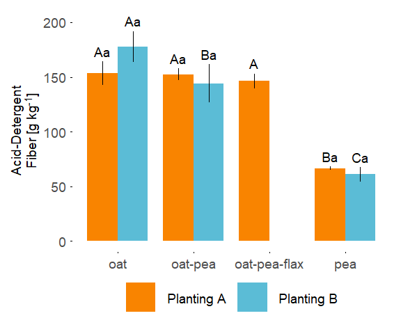

```r
plt_ADF = text_sizer(plt)
plt_ADF
```

Exact means and standard errors are:

```r
get_mean_se(paste(resp, pred, sep='~') %>% formula,
            data=df)
```

| CROP | PLANTING | COMBO_ADF.MEAN | COMBO_ADF.SE |
| --- | --- | --- | --- |
| oat | early | 153.45528 | 10.745417 |
| oat-pea | early | 152.45142 | 5.269032 |
| oat-pea-flax | early | 146.36491 | 6.632468 |
| pea | early | 66.50427 | 1.493811 |
| oat | late | 177.83696 | 13.849523 |
| oat-pea | late | 144.27763 | 17.237731 |
| pea | late | 61.00247 | 6.404488 |

## NDF

```r
resp = 'COMBO_NDF'
pred = 'CROP*PLANTING'
err = '(1|REP/PLANTING)'
dd = subset(df, CROP != 'oat-pea-flax')

# df[, resp] = df$COMBO_CP * df$COMBO_YIELD_HAND
ff = paste(resp, '~', pred, '+', err) %>%
  formula

mod = lmer(ff, data=df)
av = Anova(mod, test.statistic='F')
av
```

|  | F | Df | Df.res | Pr(>F) |
| --- | --- | --- | --- | --- |
| CROP | 58.53122914 | 3 | 15.07055 | 1.552621e-08 |
| PLANTING | 0.05860547 | 1 | 3.99022 | 8.206467e-01 |
| CROP:PLANTING | 2.15371779 | 2 | 15.07055 | 1.504188e-01 |

```r
anova_table = make_anova_table(av, append_to=anova_table)
```

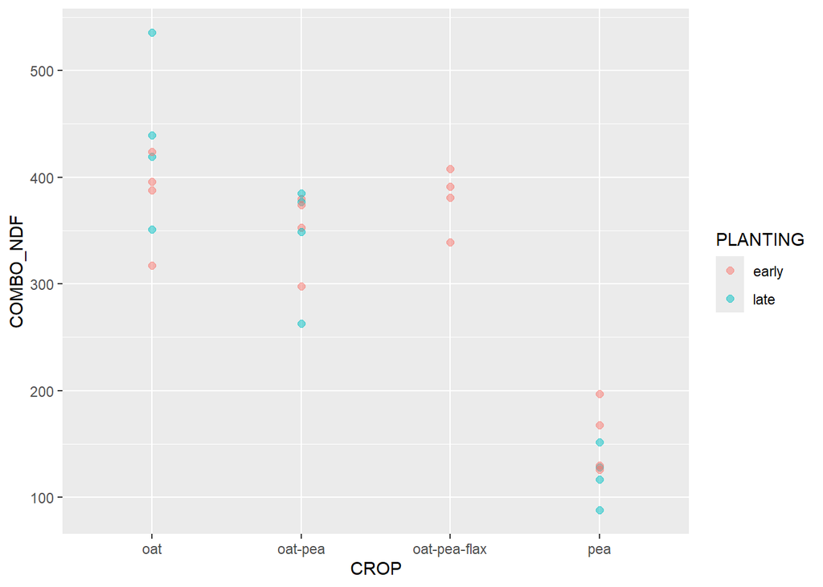

```r
ggplot(df,
       aes(x=CROP,
           y=.data[[resp]],
           color=PLANTING)) +
  geom_point(alpha=0.5,
             size=2)
```

All crops produced similar amounts of protein across planting dates, despite the very different grain ratios of the oat-pea mix.

### Comparisions

*Planting date within crop*

```r
emeans = emmeans(mod, ~PLANTING | CROP) %>%
  cld(Letters=letters,
      reverse=TRUE,
      adjust=p_adjust)
emeans
```

|  | PLANTING | CROP | emmean | SE | df | lower.CL | upper.CL | .group |
| --- | --- | --- | --- | --- | --- | --- | --- | --- |
| 1 | late | oat | 436.1750 | 23.21621 | 19.93318 | 379.90421 | 492.4458 | a |
| 2 | early | oat | 381.1000 | 23.21621 | 19.93318 | 324.82921 | 437.3708 | a |
| 4 | early | oat-pea | 351.1268 | 23.21621 | 19.93318 | 294.85602 | 407.3976 | a |
| 3 | late | oat-pea | 343.3275 | 23.21621 | 19.93318 | 287.05668 | 399.5983 | a |
| 5 | late | oat-pea-flax | NA | NA | NA | NA | NA |  |
| 6 | early | oat-pea-flax | 379.6029 | 23.21621 | 19.93318 | 331.16434 | 428.0415 | a |
| 8 | early | pea | 155.2250 | 23.21621 | 19.93318 | 98.95421 | 211.4958 | a |
| 7 | late | pea | 121.0500 | 23.21621 | 19.93318 | 64.77921 | 177.3208 | a |

*Crop within planting date*

```r
emeans1 = emmeans(mod, ~CROP | PLANTING) %>%
  cld(Letters=LETTERS,
      reverse=TRUE,
      adjust=p_adjust)
emeans1
```

|  | CROP | PLANTING | emmean | SE | df | lower.CL | upper.CL | .group |
| --- | --- | --- | --- | --- | --- | --- | --- | --- |
| 4 | oat | early | 381.1000 | 23.21621 | 19.93318 | 317.36507 | 444.8349 | A |
| 2 | oat-pea-flax | early | 379.6029 | 23.21621 | 19.93318 | 315.86798 | 443.3378 | A |
| 3 | oat-pea | early | 351.1268 | 23.21621 | 19.93318 | 287.39187 | 414.8617 | A |
| 1 | pea | early | 155.2250 | 23.21621 | 19.93318 | 91.49007 | 218.9599 | B |
| 8 | oat-pea-flax | late | NA | NA | NA | NA | NA |  |
| 6 | oat | late | 436.1750 | 23.21621 | 19.93318 | 375.50223 | 496.8478 | A |
| 5 | oat-pea | late | 343.3275 | 23.21621 | 19.93318 | 282.65470 | 404.0002 | B |
| 7 | pea | late | 121.0500 | 23.21621 | 19.93318 | 60.37723 | 181.7228 | C |

```r
colnames(emeans1) %<>% gsub('.group', '.GROUP', .)
```

*Main effects*

```r
emmeans(mod, ~CROP) %>%
  cld(Letters=letters,
      reverse=TRUE,
      adjust=p_adjust)
```

```
## NOTE: Results may be misleading due to involvement in interactions
```

|  | CROP | emmean | SE | df | lower.CL | upper.CL | .group |
| --- | --- | --- | --- | --- | --- | --- | --- |
| 4 | oat-pea-flax | NA | NA | NA | NA | NA |  |
| 2 | oat | 408.6375 | 17.17407 | 12.60684 | 361.26444 | 456.0106 | a |
| 1 | oat-pea | 347.2271 | 17.17407 | 12.60684 | 299.85408 | 394.6002 | b |
| 3 | pea | 138.1375 | 17.17407 | 12.60684 | 90.76444 | 185.5106 | c |

### Plot

Merge emmeans

```r
keep = c('PLANTING', 'CROP', '.group')

has_flax = grepl('flax', emeans$CROP)
emeans[has_flax, '.group'] = ''

emeans %<>%
  .[, keep] %>%
  merge(emeans1)

emeans[, '.group'] = with(emeans,
                          paste0(trimws(.GROUP),
                                 trimws(.group)))
```

construct plotting and labelling dataframes

```r
prettyplanting = c(early = 'Planting A',
                   late = 'Planting B')
grp = 'CROP+PLANTING'



annotate_df = c('CROP', 'PLANTING') %>%
  df[, .] %>%
  unique %>%
  merge(emeans, all.y=TRUE)
annotate_df$.group %<>% trimws()

grpY = group_Y(resp, grp, data=df)
annotate_df %<>% merge(grpY, all.x=TRUE)

pltdf = c('CROP', 'PLANTING', resp) %>%
  df[, .] %>%
  rbind(
    data.frame(CROP='oat-pea-flax' %>%
                 factor(levels=levels(df$CROP)),
               PLANTING='late' %>%
                 factor(levels=levels(df$PLANTING)),
               X=0
               )
    %>% set_names(c('CROP', 'PLANTING', resp))
  )
pltdf$prettyplanting = pltdf$PLANTING %>%
  as.character %>%
  prettyplanting[.]
annotate_df$prettyplanting = annotate_df$PLANTING %>%
  as.character %>%
  prettyplanting[.]
```

Plot

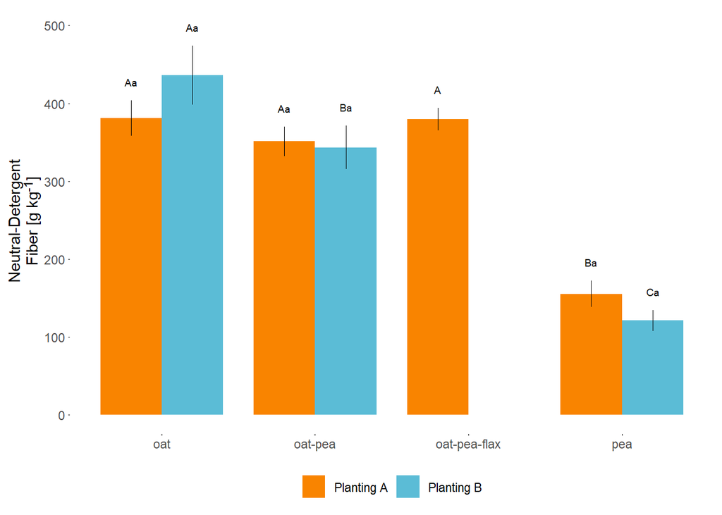

```r
dodger = position_dodge(width=0.8)

plt = ggplot(pltdf,
             aes(x=CROP,
                 y=.data[[resp]],
                 fill=prettyplanting)) +
  scale_fill_manual(values=colors[3:4]) +
  stat_summary(fun=mean,
               geom='bar',
               position=dodger,
               width=0.8) +
  stat_summary(fun.data=mean_se,
               geom='errorbar',
               width=0,
               position=dodger,
               linewidth=0.1) +
  geom_text(data=annotate_df,
            aes(x=CROP,
                y=Y,
                label=.group),
            size=2.5,
            position=dodger) +
  labs(x=NULL,
       y='Neutral-Detergent<br>Fiber [g kg<sup>-1</sup>]',
       fill=NULL)
plt %<>% gg_formatter

plt
```

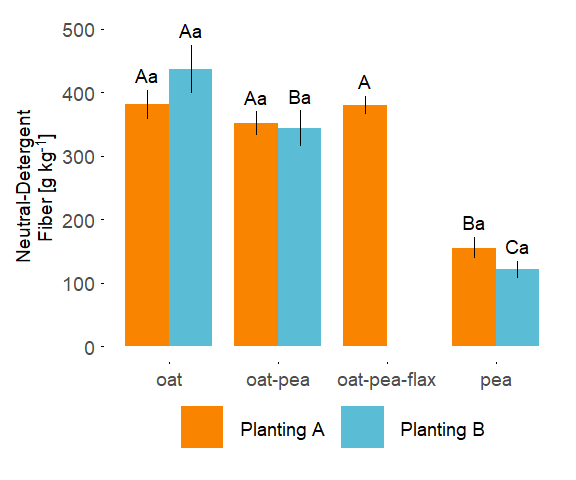

```r
plt_NDF = text_sizer(plt)
plt_NDF
```

Exact means and standard errors are:

```r
get_mean_se(paste(resp, pred, sep='~') %>% formula,
            data=df)
```

| CROP | PLANTING | COMBO_NDF.MEAN | COMBO_NDF.SE |
| --- | --- | --- | --- |
| oat | early | 381.1000 | 22.61784 |
| oat-pea | early | 351.1268 | 18.75255 |
| oat-pea-flax | early | 379.6029 | 14.64179 |
| pea | early | 155.2250 | 16.86038 |
| oat | late | 436.1750 | 38.13973 |
| oat-pea | late | 343.3275 | 27.92193 |
| pea | late | 121.0500 | 13.29640 |

## Plot Fig 4 - Quality

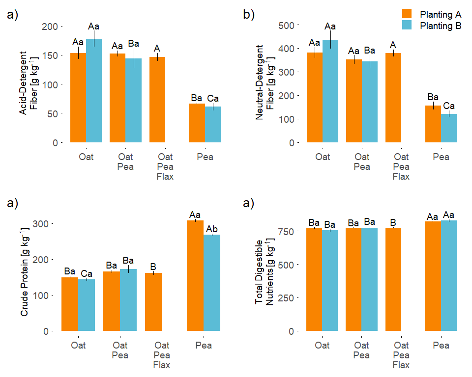

```r
xlabs = c('oat' = 'Oat',
          'oat-pea' = 'Oat\nPea',
          'oat-pea-flax' = 'Oat\nPea\nFlax',
          'pea' = 'Pea')

collabs = c('oat' = 'Oat',
          'oat-pea' = 'Oat-Pea',
          'oat-pea-flax' = 'Oat-Pea-Flax',
          'pea' = 'Pea')

p1 = plt_ADF +
  scale_x_discrete(labels=xlabs) +
  labs(tag='a)') +
  theme(legend.position='none')
p2 = plt_NDF +
  scale_x_discrete(labels=xlabs) +
  labs(tag='b)') +
  theme(legend.position=c(0.8, 1),
        legend.key.size=unit(0.12, 'in'),
        legend.title=element_text(size=8),
        axis.ticks=element_line(color='black', linewidth=0.1),
        axis.ticks.length=unit(0.3, units='mm'))
p3 = plt_protein +
  scale_x_discrete(labels=xlabs) +
  labs(tag='a)') +
  theme(legend.position='none')
p4 = plt_TDN +
  scale_x_discrete(labels=xlabs) +
  labs(tag='a)') +
  theme(legend.position='none')

marrangeGrob(grobs=list(p1, p2, p3, p4),
             layout_matrix=matrix(c(1,2,
                                    3,4),
                                  nrow=2,
                                  byrow=TRUE),
             top=NULL)
```

### Export

```r
here(out_dir,
     'Figure 4 - Grain Quality.jpg') %>%
  jpeg(width=5, height=4, units='in', res=300)

marrangeGrob(grobs=list(p1, p2, p3, p4),
             layout_matrix=matrix(c(1,2,
                                    3,4),
                                  nrow=2,
                                  byrow=TRUE),
             top=NULL)
```

```r
dev.off()
```

# Services

## Arthropods

### Egg Predation

```r
resp = 'cbind(PREDATION_EATEN, PREDATION_NOTEATEN)'
pred = 'CROP'
err = '(1|REP)'

df$PREDATION = with(df, PREDATION_EATEN/(PREDATION_EATEN + PREDATION_NOTEATEN))
dd = subset(df, PLANTING != 'late')


ff = paste(resp, '~', pred, '+', err) %>%
  formula
mod = glmer(ff, data=dd, family=binomial(link='logit'))
mod
```

```
## Generalized linear mixed model fit by maximum likelihood (Laplace
##   Approximation) [glmerMod]
##  Family: binomial  ( logit )
## Formula: cbind(PREDATION_EATEN, PREDATION_NOTEATEN) ~ CROP + (1 | REP)
##    Data: dd
##       AIC       BIC    logLik  deviance  df.resid
##  447.4163  451.2792 -218.7081  437.4163        11
## Random effects:
##  Groups Name        Std.Dev.
##  REP    (Intercept) 0.5924
## Number of obs: 16, groups:  REP, 4
## Fixed Effects:
##      (Intercept)       CROPoat-pea  CROPoat-pea-flax           CROPpea
##           -1.026             1.525             2.049             1.191
```

```r
av = Anova(mod)
av
```

|  | Chisq | Df | Pr(>Chisq) |
| --- | --- | --- | --- |
| CROP | 116.7118 | 3 | 3.940202e-25 |

```r
anova_table = make_anova_table(av, append_to=anova_table)
```

Very strong main effect.

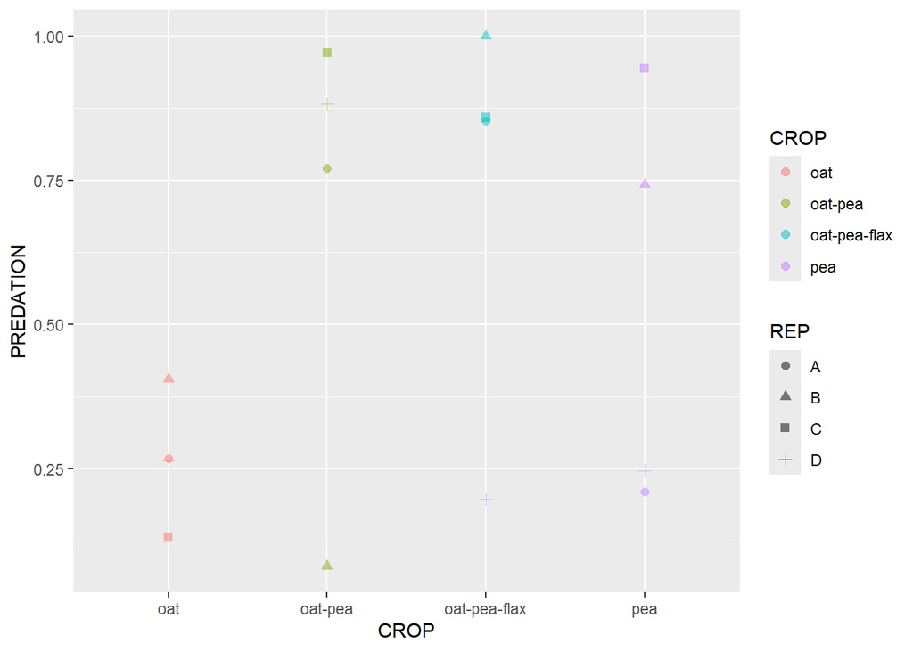

```r
resp2 = 'PREDATION'

ggplot(dd,
       aes(x=CROP,
           y=.data[[resp2]],
           color=CROP,
           shape=REP)) +
  geom_point(alpha=0.5,
             size=2)
```

```r
emeans = emmeans(mod, ~CROP) %>%
  cld(Letters=LETTERS,
      reverse=TRUE,
      p.adjust='fdr',
      type='response')
emeans
```

|  | CROP | prob | SE | df | asymp.LCL | asymp.UCL | .group |
| --- | --- | --- | --- | --- | --- | --- | --- |
| 1 | oat-pea-flax | 0.7355589 | 0.06390425 | Inf | 0.5936543 | 0.8411662 | A |
| 4 | oat-pea | 0.6222404 | 0.07616655 | Inf | 0.4660457 | 0.7566064 | B |
| 2 | pea | 0.5411189 | 0.08035419 | Inf | 0.3847567 | 0.6897825 | B |
| 3 | oat | 0.2637870 | 0.06344650 | Inf | 0.1588646 | 0.4046674 | C |

Eggs in oat-pea-flax had a 73% chance of being eaten. Oat was about 1/3 that.